# Project: Investigate a Dataset (TMDB Movies!)

- Introduction
- Data Wrangling
- Exploratory Data Analysis
- Conclusions

## Introduction

This data set contains information about 10,000 movies collected from The Movie Database (TMDb), including user ratings and revenue. We will invistagte the dataset by making desprective statistics and visulaizations to answer a specific question:

- How runtime correlate with the revenue , voting, popularity?
- Does more budget cause more revenue?
- Which genres are most popular?
- Which genres has highest revenue?
- What is the number of movies produced by companies?

```python
import numpy as np
import pandas as pd
import matplotlib.pyplot as plt
%matplotlib inline
```

## Data Wrangling

### General Properties

```python
# Read the dataset into a dataframe
df = pd.read_csv('./tmdb-movies.csv')
df.head()
```

|  | id | imdb_id | popularity | budget | revenue | original_title | cast | homepage | director | tagline | ... | overview | runtime | genres | production_companies | release_date | vote_count | vote_average | release_year | budget_adj | revenue_adj |
| --- | --- | --- | --- | --- | --- | --- | --- | --- | --- | --- | --- | --- | --- | --- | --- | --- | --- | --- | --- | --- | --- |
| 0 | 135397 | tt0369610 | 32.985763 | 150000000 | 1513528810 | Jurassic World | Chris Pratt\|Bryce Dallas Howard\|Irrfan Khan\|Vi... | http://www.jurassicworld.com/ | Colin Trevorrow | The park is open. | ... | Twenty-two years after the events of Jurassic ... | 124 | Action\|Adventure\|Science Fiction\|Thriller | Universal Studios\|Amblin Entertainment\|Legenda... | 6/9/15 | 5562 | 6.5 | 2015 | 1.379999e+08 | 1.392446e+09 |
| 1 | 76341 | tt1392190 | 28.419936 | 150000000 | 378436354 | Mad Max: Fury Road | Tom Hardy\|Charlize Theron\|Hugh Keays-Byrne\|Nic... | http://www.madmaxmovie.com/ | George Miller | What a Lovely Day. | ... | An apocalyptic story set in the furthest reach... | 120 | Action\|Adventure\|Science Fiction\|Thriller | Village Roadshow Pictures\|Kennedy Miller Produ... | 5/13/15 | 6185 | 7.1 | 2015 | 1.379999e+08 | 3.481613e+08 |
| 2 | 262500 | tt2908446 | 13.112507 | 110000000 | 295238201 | Insurgent | Shailene Woodley\|Theo James\|Kate Winslet\|Ansel... | http://www.thedivergentseries.movie/#insurgent | Robert Schwentke | One Choice Can Destroy You | ... | Beatrice Prior must confront her inner demons ... | 119 | Adventure\|Science Fiction\|Thriller | Summit Entertainment\|Mandeville Films\|Red Wago... | 3/18/15 | 2480 | 6.3 | 2015 | 1.012000e+08 | 2.716190e+08 |
| 3 | 140607 | tt2488496 | 11.173104 | 200000000 | 2068178225 | Star Wars: The Force Awakens | Harrison Ford\|Mark Hamill\|Carrie Fisher\|Adam D... | http://www.starwars.com/films/star-wars-episod... | J.J. Abrams | Every generation has a story. | ... | Thirty years after defeating the Galactic Empi... | 136 | Action\|Adventure\|Science Fiction\|Fantasy | Lucasfilm\|Truenorth Productions\|Bad Robot | 12/15/15 | 5292 | 7.5 | 2015 | 1.839999e+08 | 1.902723e+09 |
| 4 | 168259 | tt2820852 | 9.335014 | 190000000 | 1506249360 | Furious 7 | Vin Diesel\|Paul Walker\|Jason Statham\|Michelle ... | http://www.furious7.com/ | James Wan | Vengeance Hits Home | ... | Deckard Shaw seeks revenge against Dominic Tor... | 137 | Action\|Crime\|Thriller | Universal Pictures\|Original Film\|Media Rights ... | 4/1/15 | 2947 | 7.3 | 2015 | 1.747999e+08 | 1.385749e+09 |

5 rows × 21 columns

```python
# The size of the dataset
df.shape
```

```
(10866, 21)
```

```python
# A desprective Statistcs
df.describe()
```

|  | id | popularity | budget | revenue | runtime | vote_count | vote_average | release_year | budget_adj | revenue_adj |
| --- | --- | --- | --- | --- | --- | --- | --- | --- | --- | --- |
| count | 10866.000000 | 10866.000000 | 1.086600e+04 | 1.086600e+04 | 10866.000000 | 10866.000000 | 10866.000000 | 10866.000000 | 1.086600e+04 | 1.086600e+04 |
| mean | 66064.177434 | 0.646441 | 1.462570e+07 | 3.982332e+07 | 102.070863 | 217.389748 | 5.974922 | 2001.322658 | 1.755104e+07 | 5.136436e+07 |
| std | 92130.136561 | 1.000185 | 3.091321e+07 | 1.170035e+08 | 31.381405 | 575.619058 | 0.935142 | 12.812941 | 3.430616e+07 | 1.446325e+08 |
| min | 5.000000 | 0.000065 | 0.000000e+00 | 0.000000e+00 | 0.000000 | 10.000000 | 1.500000 | 1960.000000 | 0.000000e+00 | 0.000000e+00 |
| 25% | 10596.250000 | 0.207583 | 0.000000e+00 | 0.000000e+00 | 90.000000 | 17.000000 | 5.400000 | 1995.000000 | 0.000000e+00 | 0.000000e+00 |
| 50% | 20669.000000 | 0.383856 | 0.000000e+00 | 0.000000e+00 | 99.000000 | 38.000000 | 6.000000 | 2006.000000 | 0.000000e+00 | 0.000000e+00 |
| 75% | 75610.000000 | 0.713817 | 1.500000e+07 | 2.400000e+07 | 111.000000 | 145.750000 | 6.600000 | 2011.000000 | 2.085325e+07 | 3.369710e+07 |
| max | 417859.000000 | 32.985763 | 4.250000e+08 | 2.781506e+09 | 900.000000 | 9767.000000 | 9.200000 | 2015.000000 | 4.250000e+08 | 2.827124e+09 |

```python
# Features data types
df.dtypes
```

```
id                        int64
imdb_id                  object
popularity              float64
budget                    int64
revenue                   int64
original_title           object
cast                     object
homepage                 object
director                 object
tagline                  object
keywords                 object
overview                 object
runtime                   int64
genres                   object
production_companies     object
release_date             object
vote_count                int64
vote_average            float64
release_year              int64
budget_adj              float64
revenue_adj             float64
dtype: object
```

```python
# The relase_date format
df.release_date.iloc[0]
```

```
'6/9/15'
```

```python
# Number of the duplicated rows
sum(df.duplicated())
```

```
1
```

```python
# Number of rows with the missing values
df.isnull().any(axis=1).sum()
```

```
8874
```

```python
# Columns which have missing values
df.isnull().sum()
```

```
id                         0
imdb_id                   10
popularity                 0
budget                     0
revenue                    0
original_title             0
cast                      76
homepage                7930
director                  44
tagline                 2824
keywords                1493
overview                   4
runtime                    0
genres                    23
production_companies    1030
release_date               0
vote_count                 0
vote_average               0
release_year               0
budget_adj                 0
revenue_adj                0
dtype: int64
```

```python
# Number of uniques values of each column
df.nunique()
```

```
id                      10865
imdb_id                 10855
popularity              10814
budget                    557
revenue                  4702
original_title          10571
cast                    10719
homepage                 2896
director                 5067
tagline                  7997
keywords                 8804
overview                10847
runtime                   247
genres                   2039
production_companies     7445
release_date             5909
vote_count               1289
vote_average               72
release_year               56
budget_adj               2614
revenue_adj              4840
dtype: int64
```

### Data Cleaning (Replace missing values - Remove duplicated rows - Fix datatypes)

After the overview lookup at the dataset:

- We have 10866 examples of rows with 21 features of columns.
- There is only one duplicated row.
- There are 8874 rows has missing values
- Columns sepreated by | are [keywords, cast, genres, production_companies].
- Columns with missing values are ['imdb_id', 'cast', 'homepage', 'director', 'tagline', 'keywords', 'overview', 'genres', 'production_companies'].
- All users are unique except one.
- More than 50% of records have revenue and budget value as 0.

The Setps to cleaning the data will be as the following:

1. Drop inconsistent columns
2. Drop duplicated row
3. Drop null rows
4. Drop rows which have revenue and budget value as 0
5. Fix datatype of release_data column

```python
# Drop inconsistent Columns
df.drop(['id', 'imdb_id', 'homepage', 'overview'], axis=1, inplace=True)
df.head(2)
```

|  | popularity | budget | revenue | original_title | cast | director | tagline | keywords | runtime | genres | production_companies | release_date | vote_count | vote_average | release_year | budget_adj | revenue_adj |
| --- | --- | --- | --- | --- | --- | --- | --- | --- | --- | --- | --- | --- | --- | --- | --- | --- | --- |
| 0 | 32.985763 | 150000000 | 1513528810 | Jurassic World | Chris Pratt\|Bryce Dallas Howard\|Irrfan Khan\|Vi... | Colin Trevorrow | The park is open. | monster\|dna\|tyrannosaurus rex\|velociraptor\|island | 124 | Action\|Adventure\|Science Fiction\|Thriller | Universal Studios\|Amblin Entertainment\|Legenda... | 6/9/15 | 5562 | 6.5 | 2015 | 1.379999e+08 | 1.392446e+09 |
| 1 | 28.419936 | 150000000 | 378436354 | Mad Max: Fury Road | Tom Hardy\|Charlize Theron\|Hugh Keays-Byrne\|Nic... | George Miller | What a Lovely Day. | future\|chase\|post-apocalyptic\|dystopia\|australia | 120 | Action\|Adventure\|Science Fiction\|Thriller | Village Roadshow Pictures\|Kennedy Miller Produ... | 5/13/15 | 6185 | 7.1 | 2015 | 1.379999e+08 | 3.481613e+08 |

```python
# Drop duplicated rows
df.drop_duplicates(inplace=True)
```

```python
# Check if there is any duplicated row
sum(df.duplicated())
```

```
0
```

```python
# Drop records with null values
df.dropna(inplace=True)
```

```python
# Check null value exsitance
df.isnull().sum().any()
```

```
False
```

```python
# Drop recorods which have revenue and budget value as 0
df.drop(df[df['revenue'] == 0].index, inplace = True)
df.drop(df[df['budget'] == 0].index, inplace = True)
```

```python
# Check statistcs
df.describe()
```

|  | popularity | budget | revenue | runtime | vote_count | vote_average | release_year | budget_adj | revenue_adj |
| --- | --- | --- | --- | --- | --- | --- | --- | --- | --- |
| count | 3445.000000 | 3.445000e+03 | 3.445000e+03 | 3445.000000 | 3445.000000 | 3445.000000 | 3445.000000 | 3.445000e+03 | 3.445000e+03 |
| mean | 1.268127 | 3.937705e+07 | 1.166624e+08 | 109.403193 | 573.448186 | 6.184383 | 2001.038897 | 4.680125e+07 | 1.484486e+08 |
| std | 1.533870 | 4.329284e+07 | 1.830498e+08 | 19.694966 | 915.245414 | 0.788992 | 11.379944 | 4.568443e+07 | 2.237649e+08 |
| min | 0.010335 | 1.000000e+00 | 2.000000e+00 | 26.000000 | 10.000000 | 2.200000 | 1960.000000 | 9.693980e-01 | 2.861934e+00 |
| 25% | 0.507078 | 1.100000e+07 | 1.697446e+07 | 96.000000 | 86.000000 | 5.700000 | 1995.000000 | 1.500000e+07 | 2.336535e+07 |
| 50% | 0.876503 | 2.500000e+07 | 5.203489e+07 | 106.000000 | 238.000000 | 6.200000 | 2004.000000 | 3.245007e+07 | 7.121257e+07 |
| 75% | 1.464555 | 5.100000e+07 | 1.382591e+08 | 119.000000 | 631.000000 | 6.700000 | 2010.000000 | 6.420938e+07 | 1.775120e+08 |
| max | 32.985763 | 4.250000e+08 | 2.781506e+09 | 338.000000 | 9767.000000 | 8.400000 | 2015.000000 | 4.250000e+08 | 2.827124e+09 |

```python
# Convert release_data datatype to datetime datatype
df['release_date']= pd.to_datetime(df['release_date'])
```

```python
# Explode genres column
df_genre = df.assign(genre=df['genres'].str.split('|')).explode('genre')
df_company = df.assign(production_company=df['production_companies'].str.split('|')).explode('production_company')
```

```python
df_genre.head()
```

|  | popularity | budget | revenue | original_title | cast | director | tagline | keywords | runtime | genres | production_companies | release_date | vote_count | vote_average | release_year | budget_adj | revenue_adj | genre |
| --- | --- | --- | --- | --- | --- | --- | --- | --- | --- | --- | --- | --- | --- | --- | --- | --- | --- | --- |
| 0 | 32.985763 | 150000000 | 1513528810 | Jurassic World | Chris Pratt\|Bryce Dallas Howard\|Irrfan Khan\|Vi... | Colin Trevorrow | The park is open. | monster\|dna\|tyrannosaurus rex\|velociraptor\|island | 124 | Action\|Adventure\|Science Fiction\|Thriller | Universal Studios\|Amblin Entertainment\|Legenda... | 2015-06-09 | 5562 | 6.5 | 2015 | 1.379999e+08 | 1.392446e+09 | Action |
| 0 | 32.985763 | 150000000 | 1513528810 | Jurassic World | Chris Pratt\|Bryce Dallas Howard\|Irrfan Khan\|Vi... | Colin Trevorrow | The park is open. | monster\|dna\|tyrannosaurus rex\|velociraptor\|island | 124 | Action\|Adventure\|Science Fiction\|Thriller | Universal Studios\|Amblin Entertainment\|Legenda... | 2015-06-09 | 5562 | 6.5 | 2015 | 1.379999e+08 | 1.392446e+09 | Adventure |
| 0 | 32.985763 | 150000000 | 1513528810 | Jurassic World | Chris Pratt\|Bryce Dallas Howard\|Irrfan Khan\|Vi... | Colin Trevorrow | The park is open. | monster\|dna\|tyrannosaurus rex\|velociraptor\|island | 124 | Action\|Adventure\|Science Fiction\|Thriller | Universal Studios\|Amblin Entertainment\|Legenda... | 2015-06-09 | 5562 | 6.5 | 2015 | 1.379999e+08 | 1.392446e+09 | Science Fiction |
| 0 | 32.985763 | 150000000 | 1513528810 | Jurassic World | Chris Pratt\|Bryce Dallas Howard\|Irrfan Khan\|Vi... | Colin Trevorrow | The park is open. | monster\|dna\|tyrannosaurus rex\|velociraptor\|island | 124 | Action\|Adventure\|Science Fiction\|Thriller | Universal Studios\|Amblin Entertainment\|Legenda... | 2015-06-09 | 5562 | 6.5 | 2015 | 1.379999e+08 | 1.392446e+09 | Thriller |
| 1 | 28.419936 | 150000000 | 378436354 | Mad Max: Fury Road | Tom Hardy\|Charlize Theron\|Hugh Keays-Byrne\|Nic... | George Miller | What a Lovely Day. | future\|chase\|post-apocalyptic\|dystopia\|australia | 120 | Action\|Adventure\|Science Fiction\|Thriller | Village Roadshow Pictures\|Kennedy Miller Produ... | 2015-05-13 | 6185 | 7.1 | 2015 | 1.379999e+08 | 3.481613e+08 | Action |

```python
df_company.head()
```

|  | popularity | budget | revenue | original_title | cast | director | tagline | keywords | runtime | genres | production_companies | release_date | vote_count | vote_average | release_year | budget_adj | revenue_adj | production_company |
| --- | --- | --- | --- | --- | --- | --- | --- | --- | --- | --- | --- | --- | --- | --- | --- | --- | --- | --- |
| 0 | 32.985763 | 150000000 | 1513528810 | Jurassic World | Chris Pratt\|Bryce Dallas Howard\|Irrfan Khan\|Vi... | Colin Trevorrow | The park is open. | monster\|dna\|tyrannosaurus rex\|velociraptor\|island | 124 | Action\|Adventure\|Science Fiction\|Thriller | Universal Studios\|Amblin Entertainment\|Legenda... | 2015-06-09 | 5562 | 6.5 | 2015 | 1.379999e+08 | 1.392446e+09 | Universal Studios |
| 0 | 32.985763 | 150000000 | 1513528810 | Jurassic World | Chris Pratt\|Bryce Dallas Howard\|Irrfan Khan\|Vi... | Colin Trevorrow | The park is open. | monster\|dna\|tyrannosaurus rex\|velociraptor\|island | 124 | Action\|Adventure\|Science Fiction\|Thriller | Universal Studios\|Amblin Entertainment\|Legenda... | 2015-06-09 | 5562 | 6.5 | 2015 | 1.379999e+08 | 1.392446e+09 | Amblin Entertainment |
| 0 | 32.985763 | 150000000 | 1513528810 | Jurassic World | Chris Pratt\|Bryce Dallas Howard\|Irrfan Khan\|Vi... | Colin Trevorrow | The park is open. | monster\|dna\|tyrannosaurus rex\|velociraptor\|island | 124 | Action\|Adventure\|Science Fiction\|Thriller | Universal Studios\|Amblin Entertainment\|Legenda... | 2015-06-09 | 5562 | 6.5 | 2015 | 1.379999e+08 | 1.392446e+09 | Legendary Pictures |
| 0 | 32.985763 | 150000000 | 1513528810 | Jurassic World | Chris Pratt\|Bryce Dallas Howard\|Irrfan Khan\|Vi... | Colin Trevorrow | The park is open. | monster\|dna\|tyrannosaurus rex\|velociraptor\|island | 124 | Action\|Adventure\|Science Fiction\|Thriller | Universal Studios\|Amblin Entertainment\|Legenda... | 2015-06-09 | 5562 | 6.5 | 2015 | 1.379999e+08 | 1.392446e+09 | Fuji Television Network |
| 0 | 32.985763 | 150000000 | 1513528810 | Jurassic World | Chris Pratt\|Bryce Dallas Howard\|Irrfan Khan\|Vi... | Colin Trevorrow | The park is open. | monster\|dna\|tyrannosaurus rex\|velociraptor\|island | 124 | Action\|Adventure\|Science Fiction\|Thriller | Universal Studios\|Amblin Entertainment\|Legenda... | 2015-06-09 | 5562 | 6.5 | 2015 | 1.379999e+08 | 1.392446e+09 | Dentsu |

```python
# Print Information about the dataset after cleaning
df.info()
```

```
<class 'pandas.core.frame.DataFrame'>
Int64Index: 3445 entries, 0 to 10848
Data columns (total 17 columns):
 #   Column                Non-Null Count  Dtype
---  ------                --------------  -----
 0   popularity            3445 non-null   float64
 1   budget                3445 non-null   int64
 2   revenue               3445 non-null   int64
 3   original_title        3445 non-null   object
 4   cast                  3445 non-null   object
 5   director              3445 non-null   object
 6   tagline               3445 non-null   object
 7   keywords              3445 non-null   object
 8   runtime               3445 non-null   int64
 9   genres                3445 non-null   object
 10  production_companies  3445 non-null   object
 11  release_date          3445 non-null   datetime64[ns]
 12  vote_count            3445 non-null   int64
 13  vote_average          3445 non-null   float64
 14  release_year          3445 non-null   int64
 15  budget_adj            3445 non-null   float64
 16  revenue_adj           3445 non-null   float64
dtypes: datetime64[ns](1), float64(4), int64(5), object(7)
memory usage: 484.5+ KB
```

```python
# Print the size
df.shape, df_genre.shape
```

```
((3445, 17), (9301, 18))
```

## Exploratory Data Analysis

### single-variable explorations using Histogram

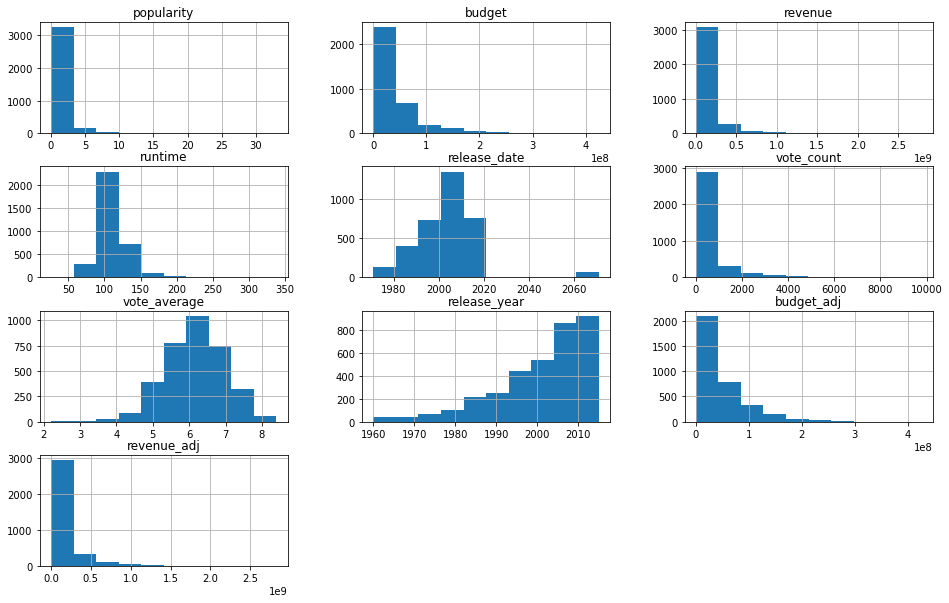

```python
df.hist(figsize=(16, 10));
```

### Research Question 1 (How runtime correlate with the revenue , voting, popularity?)

The runtime which has the most revenue is between 80 to 200.

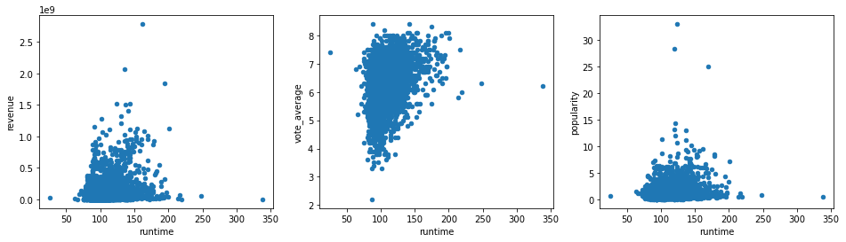

```python
figure, axes = plt.subplots(1, 3, figsize=(16,4))
df.plot(x='runtime', y='revenue', kind='scatter', ax=axes[0]);
df.plot(x='runtime', y='vote_average', kind='scatter', ax=axes[1]);
df.plot(x='runtime', y='popularity', kind='scatter', ax=axes[2]);
```

### Research Question 2 (Does more budget cause more revenue?)

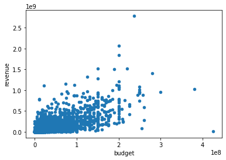

```python
df.plot(x='budget', y='revenue', kind='scatter');
```

### Research Question 3 (Which genres are most popular?)

Action, Drama, and Thriller are the most three popular genres

```python
def get_relation(df,col_1, col_2):
    col_1_classes = df[col_1].unique()
    relation_dict = {}
    for c in col_1_classes:
        df1 = df[df[col_1] == c]
        relation_dict[c] = df1[col_2].sum()

    rel = pd.DataFrame(relation_dict.items(), columns=[col_1, col_2])
    rel.sort_values(by=[col_2], inplace=True, ascending=False)
    return rel
```

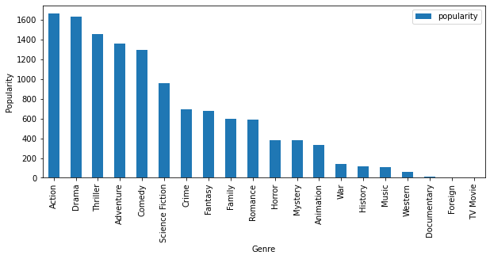

```python
genre_pop_df = get_relation(df_genre, 'genre', 'popularity')
genre_pop_df.plot(figsize=(10, 4), x='genre', y='popularity', kind='bar', xlabel='Genre', ylabel='Popularity');
```

### Research Question 4 (Which genres has highest revenue?)

Action, Adventure, and Comdey are the higest in revenue

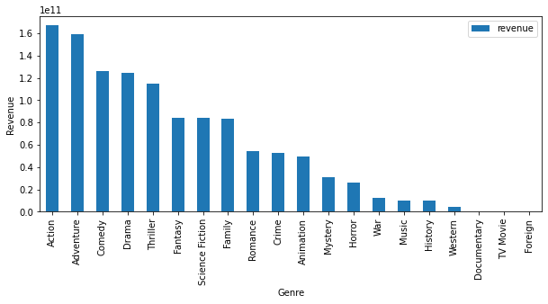

```python
genre_pop_df = get_relation(df_genre, 'genre', 'revenue')
genre_pop_df.plot(figsize=(10, 4), x='genre', y='revenue', kind='bar', xlabel='Genre', ylabel='Revenue');
```

### Resreach Question 5 (What is the number of movies in each genre?)

Drama, Comedy, and Thriller are the most common genres in movies

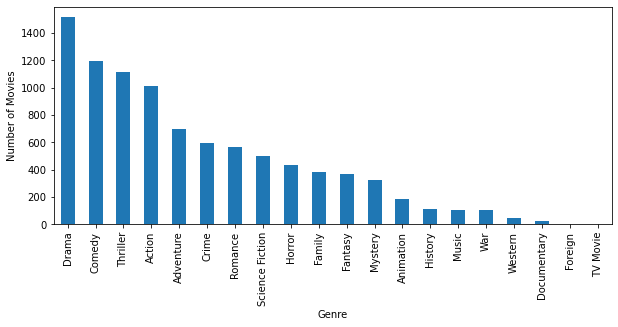

```python
genres = df_genre.genre.value_counts(ascending=False)
genres.plot(figsize=(10, 4), kind='bar', xlabel='Genre', ylabel='Number of Movies');
```

### Resreach Question 6 (What is the number of movies produced by companies?)

Universal Picture, Wamer Bros, and Paramount Picture have the thighest number of produced movies

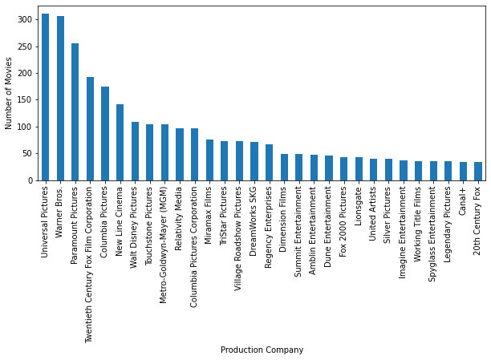

```python
companies = df_company.production_company.value_counts(ascending=False)
companies[:30].plot(figsize=(10, 4), kind='bar', xlabel='Production Company', ylabel='Number of Movies');
```

## Conclusions

### Limitation

- Predict the movie popularity and average voting using inferential statistics